# Exploring the Attitudes of Aucklanders on “Offline Leisure Activities”

## Common Hobbies

### Kiwis Like to Move It Move It! Or Maybe Not..

At the time of synthesising this data report, my sample size of 38 individuals finds that number 1 offline leisure activity is amongst New Zealanders/“Kiwis” (in Auckland) is:

…Drumroll please…

## “Exercising/sports!”

Don’t believe me?? See for yourself!

## Figure 1A:

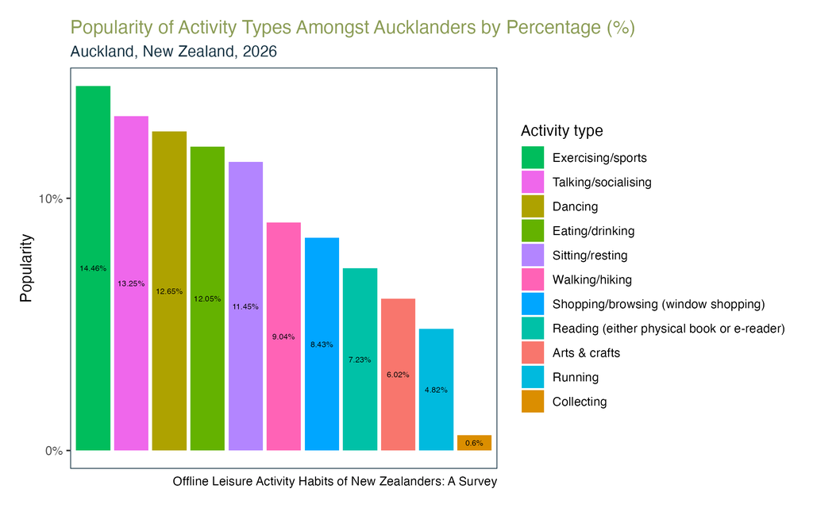

And for those that like their “just desserts”, the same information has been laid out a a pie-chart below:

## Figure 1B:

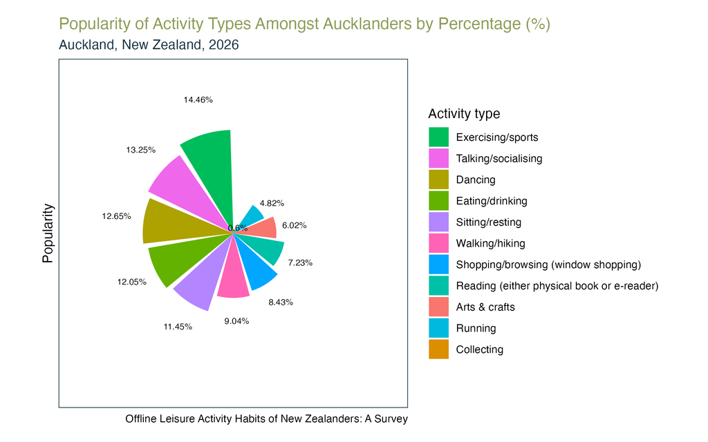

From the above figures, we can also see that “Talking/socialising”, and “Dancing” *almost* tie, following closely in second and third respectively.

## However…

It is also important to consider that only *two out of the **top five*** activity types directly involve physical movement; and only 4 out of the 11. So maybe we’re not so physically active after all… But, at least, we still seem to engage in leisurely activities outside of *just* the online world! I’d like to say that we’re not quite techno-slaves to “Skynet” just yet.

The responses used in the above figures were taken from the question:

*“What type of offline leisure activities do you engage in? (Please select one, or multiple answers).”*

Here, the popularity score of each activity type was calculated as percentages of the total amount of responses. Respondents were able to select multiple activity types. In other words, an activity that scores “100%” would mean that everyone in the survey picked **ONLY** said activity, whilst smaller percentage scores indicate that less responses selected for said activity. Naturally, activity types not mentioned in the graph were those which were not selected for, or responded with. It is wholly possible, and likely, that respondents simply “forgot” about some of the offline leisure activities that they engage in throughout the week – because it’s so natural to them! Additionally, this survey did not look into the kinds of, or the time that people spend on, online hobbies. The small sample size (n = 38) used in this project also greatly limits generalisability of my results. As such, assuming that offline leisure activities (particularly of the physical kind) are better for human wellbeing compared to online alternatives, it is difficult to conclude whether or not New Zealanders practice hobbies that *are mostly* condusive to healthy wellbeing. Yet, these results are promising.

Taken together, even in this modern age of technology – where we seem to be enslaved by the “de*vices*” meant to serve as our tools – it is nice to know that many of us still actively, physically engage with our bodies and the environments surrounding us.

## Stress vs Work Hours

### How does being a “busy body” affect our experience of leisure?

Often, leisure activities and hobbies (in this case specfically offline in nature) play an important, “de-compression”, role in relieving stress from work, studies, adverse life events, and daily life. But what about when we feel so stressed that we cannot fully engage in the OLA to reap its benefits? As a preliminary exploration into the quality of Aucklanders’ engagement in OLAs, I used “urgency ratings” as a proxy for stress.

That is, I asked my participants:

*“7. On a scale of 1 to 5, how often do you feel rushed when engaging in your offline leisure activities? (1 = Not rushed at all, 5 = Extremely rushed)”*.

The results from their responses can be viewed in the below two figures:

## Figure 2A:

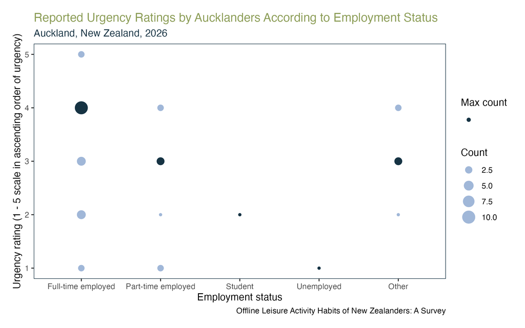

First, I wanted to know whether there any observable patterns might emerge between groups, according to their employment status. That is, whether or not people might feel more or less urgency depending on their status of employment. Indeed, we can see that Figure 2A indicates that individuals working “Full-time” typically feel the greatest amount of urgency when engaging in OLAs, followed by individuals who work “Part-time” and are in “Other” statuses of employment, then “Student(s)”, then “Unemployed”. The “Other” category may involve freelance workers and/or gig workers, seasonal workers, stay-at-home parents, and/or those who cannot work due to illness/disability, etc.

## Figure 2B:

*“3. How many hours a week, on average, do you spend working (or studying if you are a student – including time spent on assessments)?*

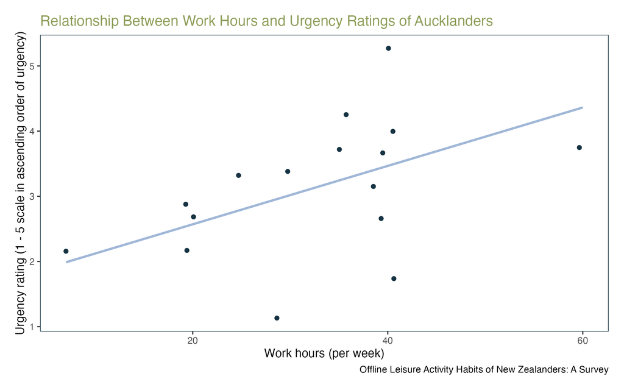

Indeed, as we can see in Figure 2B, people that work more seemed to feel more stressed when they engage in OLA. Corroborated by specified work hours in the updated survey.

## Survey Habits?

### When are people most likely to engage with research surveys?

This small research project offered a lot of great preliminary insights into our OLA habits, and the relationship between OLAs, stress, and work! However, they have very limited power in infering whether stress does affect enjoyment, any benefits to be gained, and does not add to the body of literature evaluating offline leisure activities against online alternatives.

Going forward, there is much to learn from gathering more data on our communities’ experiences about the matter. In order to do so effectively however, it may be useful to understand when to roll out promotional material for future surveys.

The below figure looks into when (day of the week and time of day) individuals typically engaged with my survey.

## Figure 3:

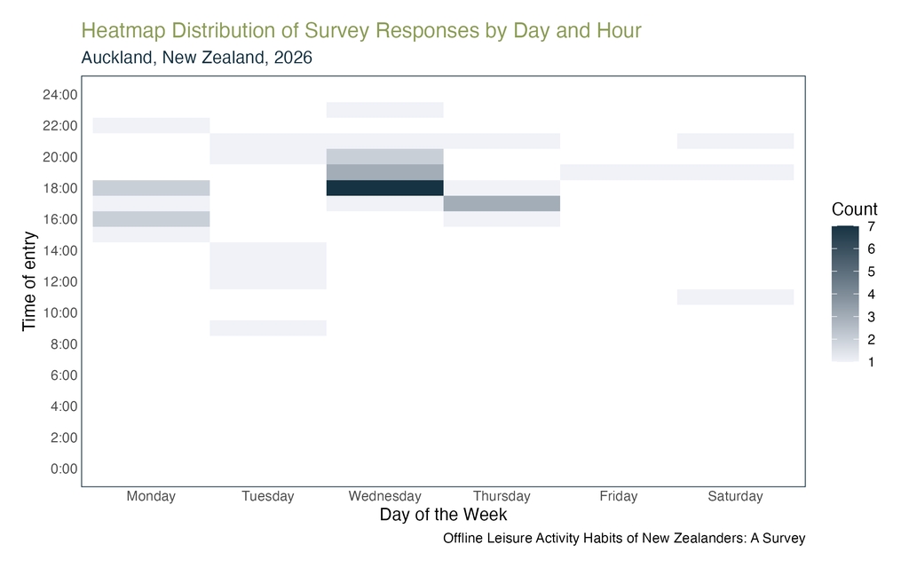

Here, darker colour bands indicate more responses during a given day and time, whilst lighter colouurs indicate the opposite, along a gradient. We can see that, according to my sample, Aucklanders reply best mid-week. Specifically, Wednesday around 6 to 8pm (i.e., 18:00 to 20:00 in 24 hour time). Whilst, there may be many reasons for this, it is possible that this is when people typically feel better settled into their workload for the week and thereby have greater capacity to engage in extracurricular surveys. Additionally, people seemed less likely to engage in surveys later in the week.

## Curious Questions Going Forward:

1. Are these patterns consistent with online leisure activities?
2. Does an individual’s sense of urgency affect the beneficial effects of engaging in a leisure activity (i.e., are physical, mental, and other aspects of wellbeing benefited equally across urgency ratings?